# An Amalgamation of chpts 2-4!

Rae Dunbar

10/29/2022

In this data frame we will use programming and techniques learned in chapters two to four.

## Setting up R

```r
rm(list=ls()) #clear R's memory
#Adding necessary packages
library(here)
library(dplyr)
```

```r
library(ggplot2)
```

## Pulling in the Data

Given this is due oon halloween we will be working with halloween data!

```r
here() #See where R is looking
```

```
## [1] "/home/rldunb19/Biostats Senior Fall/Biostats-Problem-Sets"
```

```r
halloween<- read.csv(here("Problem-Set-2", "Data for the code", "Halloween_data_PS2.csv"), stringsAsFactors = TRUE)
#I needed to first bring R into my Problem set 2 folder, since R was looking just in the project.
#Given we wanted both Costume and Type as factors and not as character, I did stringsAsFactors=TRUE to make them factor variables right away.
```

## Examine the Data

```r
names(halloween) #shows column names
```

```
## [1] "Costume"      "Type"         "candy_pieces" "age"
```

All column names seem to spelled correctly, and there are no dots indicating unwanted spaces, so we can keep the column names.

It looks like the data has four variables, the costume, Type, the number of candy pieces, and the age of what I presume is the costume wearer. To understand what “Type” means and see the spread of the data lets use summary:

```r
summary(halloween) # provides a summary of the data
```

```
##          Costume          Type     candy_pieces         age
##  Zombie      : 7   Not scary:28   Min.   : 1.000   Min.   : 4.000
##  Unicorn     : 6   scary    : 2   1st Qu.: 1.000   1st Qu.: 6.000
##  Mouse       : 5   Scary    :15   Median : 2.000   Median : 8.000
##  Rabbit      : 5   scary    : 1   Mean   : 2.909   Mean   : 8.727
##  Mermaid     : 4                  3rd Qu.: 4.000   3rd Qu.:11.250
##  wonder woman: 4                  Max.   :16.000   Max.   :15.000
##  (Other)     :15                  NA's   :2        NA's   :2
```

Type appears to be whether the costume is scary or not. There are four levels for ‘Type’ and three of which are ‘scary.’ I see the error in one of the entries, since it has the S capitalized, but the other two look exactly the same. Lets see if running levels helps clarify that.

```r
levels(halloween$Type) #shows the choices available for the column.
```

```
## [1] "Not scary" "scary"     "Scary"     "scary "
```

Now I see there is a space right after one of the ‘scary’ datum. So, we need to fix that to have the correct number of levels in that column. For the other two variables, the max number of candy peices being 16 is probably an outlier, given the mean is 2.9 and the third quartile is only 4. The age data look reasonable. Lets double check the possbility of an outlier by looking at more of the data with another.

```r
tbl_df(halloween) # make a table of your data
```

```
## # A tibble: 46 × 4
##    Costume      Type      candy_pieces   age
##    <fct>        <fct>            <int> <int>
##  1 wonder woman Not scary            2     8
##  2 wonder woman Not scary            1     9
##  3 Wonder Woman Not scary            1    10
##  4 Wonder woman Not scary            3    NA
##  5 wonder woman Not scary            2     8
##  6 wonder woman Not scary            1     9
##  7 Wonder woman Not scary            1    10
##  8 Wonder woman Not scary            1    10
##  9 creepy clown Scary                4    14
## 10 clown        Scary                3    13
## # … with 36 more rows
```

Aside from the wopping 16 candies, the biggest number is 6, making 16 an outlier. The age distribution is, as I aspected based on the mean, reasonable.There are 13 and 14 year old children, with the eldest being 15. It is feasible one child was particularly victorious with candy, so we will leave the outlier in the data. Based on how it impacts the figures we may want to leave it out later.

I noticed another issue however, some entries are spelled differently, so there are costumes that are the same, but R thinks they are different.

## Fixing the Data

```r
sfix<-which(halloween$Type== "Scary" | halloween$Type== "scary " )
halloween$Type[sfix]<- "scary"
```

### checking that it was fixed

```r
tbl_df(halloween)
```

```
## # A tibble: 46 × 4
##    Costume      Type      candy_pieces   age
##    <fct>        <fct>            <int> <int>
##  1 wonder woman Not scary            2     8
##  2 wonder woman Not scary            1     9
##  3 Wonder Woman Not scary            1    10
##  4 Wonder woman Not scary            3    NA
##  5 wonder woman Not scary            2     8
##  6 wonder woman Not scary            1     9
##  7 Wonder woman Not scary            1    10
##  8 Wonder woman Not scary            1    10
##  9 creepy clown scary                4    14
## 10 clown        scary                3    13
## # … with 36 more rows
```

It looks like it worked! So, now we need to re-asign the factors so R can keep up with our changes.

### Change the Factors

```r
halloween$Type<- factor(halloween$Type)
# Assign the factors that are now in the column Type to the column Type.
```

```r
levels(halloween$Type)
```

```
## [1] "Not scary" "scary"
```

### Fixing the Costume types

```r
levels(halloween$Costume)
```

```
##  [1] "clown"        "creepy clown" "Creepy clown" "Mermaid"      "Mouse"
##  [6] "pirate"       "Rabbit"       "Unicorn"      "witch"        "Witch"
## [11] "witch "       "wonder woman" "Wonder woman" "Wonder Woman" "Zombie"
```

```r
cfix<-which(halloween$Costume== "creepy clown" | halloween$Costume== "clown" )
halloween$Costume[cfix]<- "Creepy clown"

wfix<-which(halloween$Costume== "witch" | halloween$Costume== "witch " )
halloween$Costume[wfix]<- "Witch"

wwfix<-which(halloween$Costume== "wonder woman" | halloween$Costume== "Wonder Woman" )
halloween$Costume[wwfix]<- "Wonder woman"
```

### Reseting the Levels

```r
halloween$Costume<- factor(halloween$Costume)
levels(halloween$Costume)
```

```
## [1] "Creepy clown" "Mermaid"      "Mouse"        "pirate"       "Rabbit"
## [6] "Unicorn"      "Witch"        "Wonder woman" "Zombie"
```

Now we have the proper number of factors

## Calculating Mean

```r
halloween_means<-halloween %>% group_by(Costume, Type) %>% summarize(mean_candy=mean(candy_pieces, na.rm=TRUE), mean_age=mean(age, na.rm=TRUE))
#na.rm tells R to ignore the NA data and calculate the mean anyway.
```

The zombie costume had the highest mean candy count, thoough the outlier may have skewed that. And the unicorn costumes received the least amount. Creepy clowns had the highest mean age with rabbits having the lowest. Lets see this in graph form.

## Making Graphs

### Graph 1

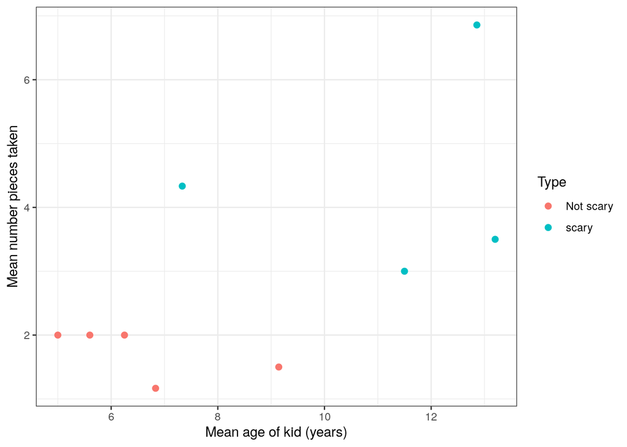

```r
ggplot(data=halloween_means, aes(x=mean_age, y=mean_candy, colour=Type)) + xlab("Mean age of kid (years)") + ylab("Mean number pieces taken")+ geom_point(size=2) + theme_bw()
```

```r
#use ggplot to layer a graph together first taking the data from the halloween_means table, make the x and y axis as noted and call them what is noted with xlab and ylab.Then add points, making the size 2, which seems the closest to the size you chose, and the theme of the graph black and white colored.
```

### Graph 2

Our task is to write code that isolates the data for children in “not scary” costumes who are 10years old or younger and use the resulting data to plot a histogram showing the number of kids in each age class and that comes as close as you can to replicating figure 2, below.

We need to work with the origonal halloween data for this.

```r
histogram<-halloween %>% filter(halloween$Type=="Not scary" & halloween$age<=10)
# take the halloween data and show only the data where the type is not scary and the child is 1o years or younger in a new dataframe called histogram.
```

Now we can plot this:

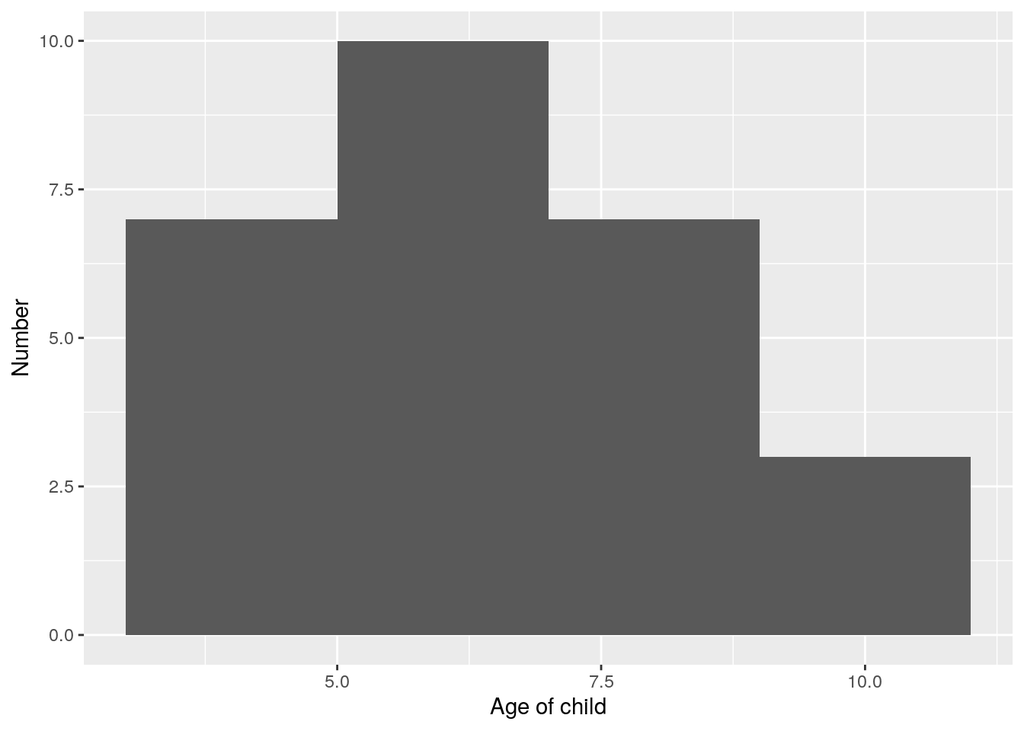

```r
ggplot(data=histogram, aes(x=age)) + xlab("Age of child") + ylab("Number") + geom_histogram(bins=4)
```